In this post, I will describe an easy method to change the font size of individual table columns in `Latex` and HTML documents. I thought about this task after reading [this Stack Overflow question](http://stackoverflow.com/questions/16424545/reduce-cell-width-and-font-size-of-table-using-pandoc-table).

I really love `pander`’s `pandoc.table` function because it wraps long strings across multiple lines. Consider the following example of a grades table for a student report card.

```r
library(pander)
grades <- data.frame(Class = c('Math', 'Reading', 'CS'),
                     Grade = c('B+', 'A-', 'C'),
                     Comments = c('Homework held you back. Make sure you get it in on time!',
                                  'Your final essay was very strong. One area of improvement is your supporting evidence. Remember to use at least two pieces for each of your assertions.',
                                  'You did very well on your homework, but your quarter project did not meet all the requirements. Based on the code, it looked like you rushed through it. Please schedule a meeting with me so we can discuss this issue.'))

knitr::kable(grades)
```

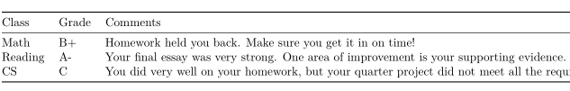

```r
pandoc.table(grades)
```

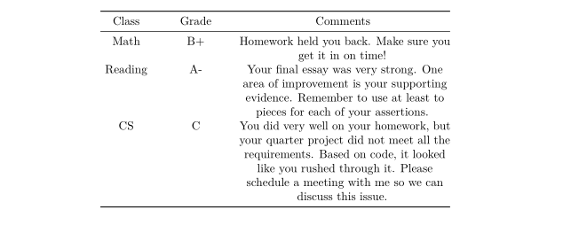

When printing tables with long strings, `pandoc.table` has a clear advantage.

Now imagine if there was limited space for the table in your document. Perhaps, there are several other tables or graphs you want to share. One way to adjust is to change the size of the font of the entire table using a code-block like `\\scriptsize`.

```r
cat('\\scriptsize')
pandoc.table(grades)
```

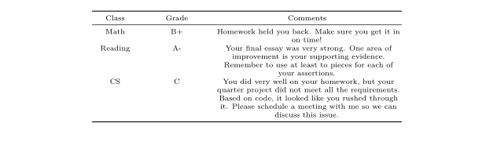

The disadvantage here is that the main pieces of information, class and grade, are difficult to read. An alternative is to only apply the new formatting to the comments column. We can accomplish this by adding the code block to the string. This is similar to the implementation of the `emphasize` arguments in `pandoc.table`.

```r
library(dplyr)
grades %>%
    mutate(Comments = paste('\\tiny', Comments)) %>%
    pandoc.table
```

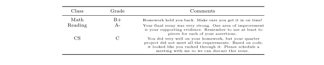

Using `<font>`, we can do the same for an HTML table.

```r
grades %>%
    mutate(Comments = paste('<font size="1">', Comments, '</font>')) %>%
    pandoc.table
```

[output not shown]

Using `Latex` and HTML tags is an easy way to add custom formatting to `pandoc.table`s. I’m curious about using `split.single.cells` and `split.large.cells` ([functions within `pandoc.table`](https://github.com/Rapporter/pander/blob/master/R/pandoc.R)) with `knitr::kable` in order to create `Latex` output with wrapped text. I’d also like to implement `cell.height` functionality so rows have a uniform height. Overall, it may be worth creating an `ApplyFormatting` function (in base-`R`) for more flexibility.